# Statistical Analysis of Rest and Freshness at Major International Tournaments

Kenneth Day

8/15/2021

### **Introduction**

With both the European Championships and the Copa America football tournaments coming to an end recently, I wanted to take a look at how different factors related to rest and recovery relate to a nation’s success during these major international tournaments.

For this analysis, I looked at all matches since 1993 for the World Cup, European Championship, and Copa America. I choose these three competitions because they are the three of the biggest (and highest level) national team competitions contested. Why since 1993? The first official FIFA World Rankings were released in December 1992, and I wanted to include a rankings difference when looking at individual matchups.

### **Data Collection and Integration**

##### **Match Data**

I used webscraping to get individual match data and statistics from worldfootball.net. For each match, I retrieved the match report text, and I used it to isolate several important statistics/pieces of information. These included:

- Match date
- The two nations involved
- Winning nation
- Score
- Match duration and resolution (90 minutes vs. extra time and/or penalty shootout)
- Number of subs used by both teams in regulation
- Number of minutes played by both teams’ subs in regulation
- Which team scored the last goal in regulation

In all, individual match data was collected for 994 matches (note: 3rd place matches were not included). The following table gives a breakdown of the distribution of matches between the three tournaments:

```
##               Copa America Euros World Cup
## Editions                12     7         7
## Total Matches          308   257       429
## KO Matches              84    65       105
```

##### **FIFA Rankings**

The FIFA World Ranking is a worldwide ranking of all recognized national teams from the six continental confederations (the latest May 2021 rankings had 210 nations). The methodology of the rankings have changed over the years, but the purpose has always been to generate a points value for each team that allows them to be ranked from best to worst (you can learn more about the current formula FIFA uses [here](https://digitalhub.fifa.com/m/f99da4f73212220/original/edbm045h0udbwkqew35a-pdf.pdf)). From the first FIFA rankings in December 1992 through May 2021, there have been 312 editions of the rankings, and I retrieved a comprehensive set of all of these rankings from [here](https://www.kaggle.com/cashncarry/fifaworldranking).

In order to integrate these rankings and point values with the match data, the following steps were taken:

1. A country name/id key was created that accounted for any differences in country names between the match data and the rankings data. (For example, it is listed as “South Korea” in the match data and “Korea Republic” in the rankings data)
2. For each match, both teams’ rank and rank-points were taken from the last edition of the rankings released before the first match of the tournament.

### **Data Manipulation**

With the match and ranking data collected and integrated, the next step was to manipulate the data to create the necessary variables. These included the following variables for both teams for all 994 matches:

- Date of last match played at the tournament
- Normalized rank-points (necessary due to the large discrepancy in points awarded in different editions of the rankings)
  - Calculated as $1000 {\times} \frac{\mbox{rank points}}{\mbox{total rank points}}$
- Subs used in the previous match
- Substitute minutes played in the previous match
- Subs used in the previous 3 matches
- Substitute minutes played in previous 3 matches
- Average subs used in all previous matches
- Average substitute minutes played in all previous matches
- Duration of the previous match (90 minutes vs. 120 minutes)

Note: For substitute statistics, I decided that only subs used in regulation were used. This is because the additional burden of extra time was included in the previous match duration variable. Also, if a team uses a fourth sub in extra time, having used four subs instead of three would seem to imply the team is more rested for their next match, but it would actually be the opposite because they played thirty extra minutes.

### **Data Exploration: Determining Which Variables Affect Match Outcomes**

##### **Rest**

As followers of domestic leagues know, managers often have the rest and fixture congestion excuse ready to go after coming up short in a key match (think Jürgen Klopp and José Mourinho). Intuitively, this makes a lot of sense: the fresher the team is, the harder they can play. To evaluate this claim, we can look at the matches involving teams that have a different number of days since their respective last matches.

Out of the 994 matches in the data set, there are 748 where both teams played at least one previous match in that same tournament. Of those 748 matches, this is the breakdown of difference in rest:

```
##
## Difference in Days Since Previous Match   0   1  2  3 4 5
## Count                                   399 287 45 14 1 2
```

The matches where both teams had the same amount of rest days since their last match won’t tell us anything, so that leaves us with 349 matches where the two teams have a different amount of days off since their last respective matches. For these matches, we get the following outcomes:

```
##
## Difference in Rest Days         1  2 3 4 5 Total
## Wins By Team With More Rest   118 26 6 1 0   151
## Draws                          46  3 1 0 0    50
## Losses By Team With More Rest 123 16 7 0 2   148
```

Surprisingly, these results show that rest has a minimal impact on the outcome of a match. Looking at the total column, we see that the team with more days of rest only wins 50.5% of their matches.

##### **Substitutions**

While we saw that rest doesn’t affect matches very much, what about substitutions? One might think that the more subs used (and for longer duration) in previous matches, the fresher a side will be for their future matches.

In order to examine this hypothesis, we are going to look at both the number of substitutes used and how long they played in previous matches. For both of these, I only considered subs used in regulation, as matches that go to extra time obviously impact a team’s freshness in its own way (duration of previous matches will be considered as its own factor later on). There is also the question of how many of the previous matches to consider when looking at the freshness of a team going into a match. For that, I have prepared three different options to consider: the previous match, the previous 3 matches, and all previous matches in the competition.

The best way to examine how the number of substitutes used in previous matches affects a team’s performance in their the next match is to compare the two sets corresponding to the winning and losing teams (we’ll ignore draws). That is, is there a significant difference between the previous number of subs used by winning teams and the number used by losing teams? In order to answer that question, I’ve come up with the following graphs which show average and standard deviation in regards to number of subs:

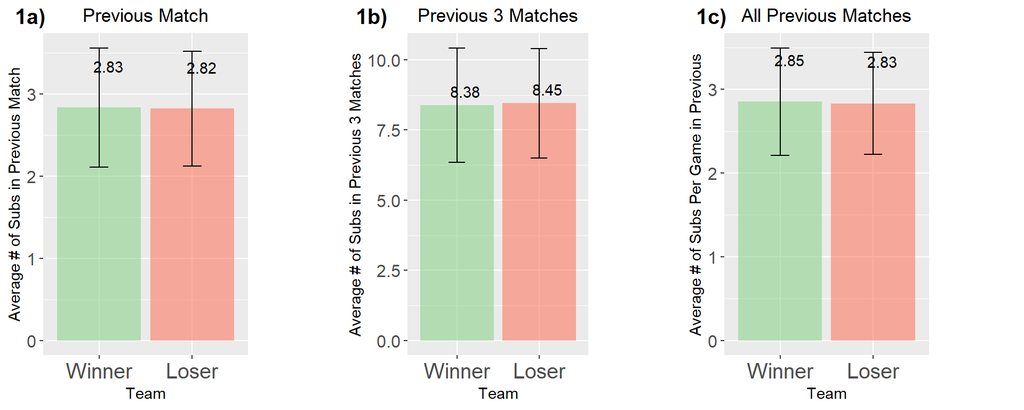

These graphs paint a very clear picture, there is no statistically significant difference between the number of previous subs used by winning and losing teams. This is true regardless of whether you look at just the last match (Figure 1a), the previous 3 matches (Figure 1b), and all previous matches (Figure 1c). Going back to our question, these results indicate that the number of subs used in previous matches isn’t correlated to a team’s chances of winning their next match.

So we’ve looked at the number of subs used, what about the number of minutes played by subs in regulation? You might think this is a more important factor in regards to how rested a team is. A sub coming on in the 60’ minute is a lot different than one coming on in the 90’ minute, right? For substitute minutes, we get the following graphs:

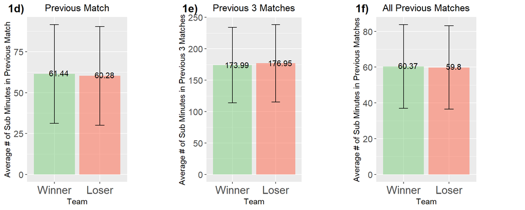

Once again, it is easy to see that the amount of time played by subs in previous matches is not significantly correlated to match outcomes.

Looking at all six graphs (Figures 1a-1f), we can conclude that there isn’t any correlation between a manager’s substitution behavior and their team’s success in the next match. That said, it’s hard to believe that the number and duration of subs doesn’t impact the next match. What could be happening here is that there are two different trends offsetting one another.

On one hand, you might assume that a team who loses the match is worse and was therefore more likely to be losing at some point during their previous match(es), and losing teams tend to make earlier substitutions (this is supported by the match data I used as the average winning team has 55.6 minutes of substitute play while the average losing team has 68.2 minutes of substitute). This train of thought would correspond with losing teams having larger values of sub minutes in previous matches than do winning teams.

On the other hand, you would think that the more comfortably a team is winning in a match, the more willing they are to make earlier substitutions. A manager doesn’t have to worry about messing up his team’s flow and rhythm if they are up 4-0. This second train of thought would correspond with winning teams having larger values of sub minutes in previous matches than do losing teams. So although we didn’t see any correlation in the data between subs and outcomes, it is probably a bad idea to declare that the use of substitutes doesn’t impact future matches.

##### **Duration of Previous Match**

So far, we have seen that there is no data to show that the number of rest days or the amount or duration of subs impacts a team’s chance of success. That leaves us with one more rest/freshness factor to consider: the duration of a previous match. For all intents and purposes here, there is really only two options for the duration: 90 minutes or 120 minutes. That is, a match either has a 30 minute extra-time or it does not.

Of the 994 matches in our data set, only 50 of them involve at least one team who played extra time in their previous match (unfortunately the majority of Copa America tournaments have been without extra-time, with tied matches heading straight to penalty shoot-outs after the 90 minutes). Of those 50 matches, we get the following breakdown:

```
##                                        Count
## Winner Played ET in Previous Match        15
## Loser Played ET in Previous Match         24
## Both Teams Played ET in Previous Match    11
```

Looking at the table, we finally seem to see some statistical difference between the winning and losing sides. In the matches where one team played extra-time in the previous match and the other team did not, the team that played those extra 30 minutes loses over 60% of the time (24/39).

To test if this percentage is significant, we can use a one sample test of proportions involving a one-sided z score to calculate a 95% confidence interval. Our null hypothesis is that the duration of a team’s previous match doesn’t affect the outcome of their next match (this would correspond to a win percentage of 50%). Our alternative hypothesis is that a team is more likely to lose if they played extra-time in their previous match (this would correspond to a win percentage of less than 50%). We can use the following formula to calculate a confidence interval for the true win percentage of teams who played extra-time in the previous match (and their opponents did not):

$p_1 \pm z_{0.05} {\times} \sqrt{\frac{p_1{\times}(1-p_1)}{n}}$, where  
$p_1 = \frac{15}{15 + 24} = \frac{15}{39} = 38.5\%$ (win percentage of data sample)  
$z_{0.05} = 1.645$ (one-sided z-score at a p-value of 0.05)  
$n = 39$ (sample size)

Plugging in, we get:

$0.385 \pm 1.645 {\times} \sqrt{\frac{0.385{\times}(1-0.385)}{39}} \rightarrow 0.385 \pm .128 \rightarrow (25.7\%, 51.3\%)$

As our 95% confidence interval includes 50%, we are unable to reject our null hypothesis that playing extra-time in the previous match doesn’t affect the chances of success in the next match.

##### **FIFA Ranking**

At this point, we haven’t seen any evidence that any of our three rest/freshness factors impact match outcomes at these major international tournaments. Something has to contribute to match outcomes, right? For the sake of the exercise, let’s pick a variable we can be almost certain affects match outcomes: the quality of a team. Obviously, this is a very subjective matter, but we are going to use the FIFA rankings to measure how good a team is. For all 994 matches in our data set, we have a corresponding FIFA ranking for both teams. Using those ranking matchups, we get the following heatmap:

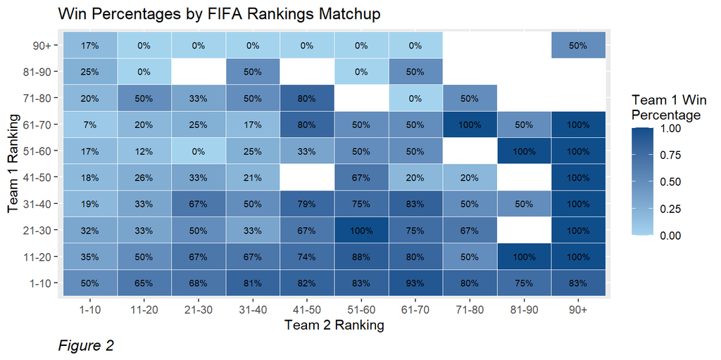

Figure 2 shows a clear relationship between the relative FIFA rankings of two opponents and the outcome of the match: the bigger the disparity, the more likely the better team is to win. This of course is not surprising. On a side note, one interesting piece of information that sticks out is that teams ranked above 90 have only ever beaten other teams ranked above 90 and teams ranked in the top 10, nothing in between. It was actually one 90+ vs. 1-10 victory that leads to the 83%, and that was when Paraguay, ranked #100, beat Mexico, ranked #7, during the 1995 Copa America group stages.

One way we can try to solve this issue is by using ranking points (which the rankings are based off of) instead of the ranking positions themselves. For these ranking points, we will use a normalized version, the calculation of which was provided earlier. For the three countries mentioned previously, we have the following FIFA ranking points: #1 Belgium - 1783 pts, #45 Jamaica - 1432 pts, and #90 Armenia - 1273 pts. These points seem to a better job showing the perceived quality difference between the three teams, with Jamaica being 351 pts away from Belgium and only 159 pts away from Armenia. For these reasons, I used FIFA ranking points as a measurement of quality. To be more specific, I used a normalized version of these ranking points, with the reasoning for and calculation of explained above in the “Data Manipulation” section.

With that in mind, we get the following scatterplot with regression line (plus confidence interval):

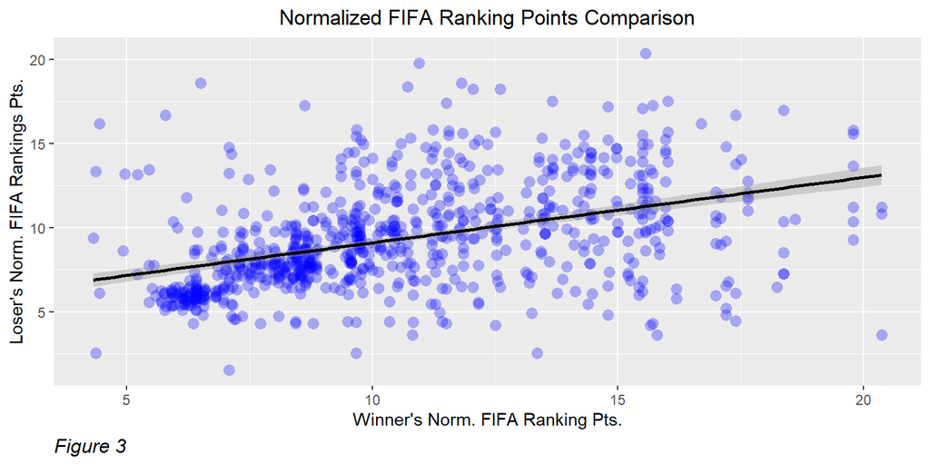

Considering how all possible trendlines in our 95% confidence interval in Figure 3 represent a positive correlation, we can conclude that there is a strong relationship between the the normalized FIFA ranking points of the winning and losing teams. For our linear regression, we get an equation of $W = 0.47{\times}L + 6.17$ and an $R^2$ value of $0.183$. The latter tells us that the normalized ranking points accounts for ~18% of the variance of the data in Figure 3.

### **Logistic Regression**

To finish up our examination of the affect rest and freshness has on the outcome of matches during the major international tournaments (World Cup, Euros, and Copa America), we can use multivariate logistic regression to examine the extent (and certainty) to which these variables determine match outcomes. I chose to use logistic regression instead of linear regression like before because we are dealing with a classification relationship (1 or 0, win or loss). Same as before, we can also include FIFA ranking points.

The data set used for this regression analysis includes the following 5 variables:

- Difference in rest days compared to opponent
- Difference in average number of substitute minutes per match in all previous matches in the competition
- Difference between extra time status of the team’s last match and opponent’s last match
  - Neither team nor opponent played extra time = 0
  - Team played extra time, opponent did not = +1
  - Opponent played extra time, team did not = -1
  - Both team and opponent played extra time = 0
- Difference in normalized FIFA ranking points
- Result
  - Win = 1
  - Loss = 0

Based on these included variables, only matches that didn’t finish in a draw and where neither team was playing in their first match were considered. Based on those requirements, we get a sample of 629 matches (out of 994). Further, for each match there are two entries in the data: one for the winner and one for the loser. That gives us a total of 1258 entries in our logistic regression data set.

Running our logistic multivariate regression, we get the following coefficients:

```
##   (Intercept)     rest_days      sub_mins    extra_time      pts_norm
## -4.834745e-16  1.443169e-02  1.789318e-03 -3.966895e-01  2.385561e-01
```

This gives us a regression formula of:

$Result = 0 + 0.0144 {\times} {\mbox{Rest Days}} + 0.0018 {\times} {\mbox{Sub Mins}} - 0.3967 {\times} {\mbox{Extra Time}} + 0.2386 {\times} {\mbox{Pts Norm}}$, where the variables used correspond to those described above.

In our data exploration earlier, we found that none of the rest/freshness variables (rest days, sub usage, and extra time) had a statistically significant link to match outcomes. We can look at the confidence levels of our regression output to confirm those findings. We get the following p-values for the different variables:

```
##  (Intercept)    rest_days     sub_mins   extra_time     pts_norm
## 1.000000e+00 8.138611e-01 3.520579e-01 1.036237e-01 3.310571e-29
```

As we suspected, none of the three rest/freshness variables reach the 0.05 threshold. The closest is the extra time variable which has a p-value of 0.104, but you have to remember that the number of matches involving at least one team who played extra time in their previous match is quite small (only 50). That said, the only thing in our data that significantly impacts the outcome is the normalized FIFA ranking points (with its p-value being smaller than $10^{-28}$).

Applying our regression model to our data, we get the following outcome predictions, where an output over 0.5 corresponds to a win and an output less than 0.5 corresponds to a loss:

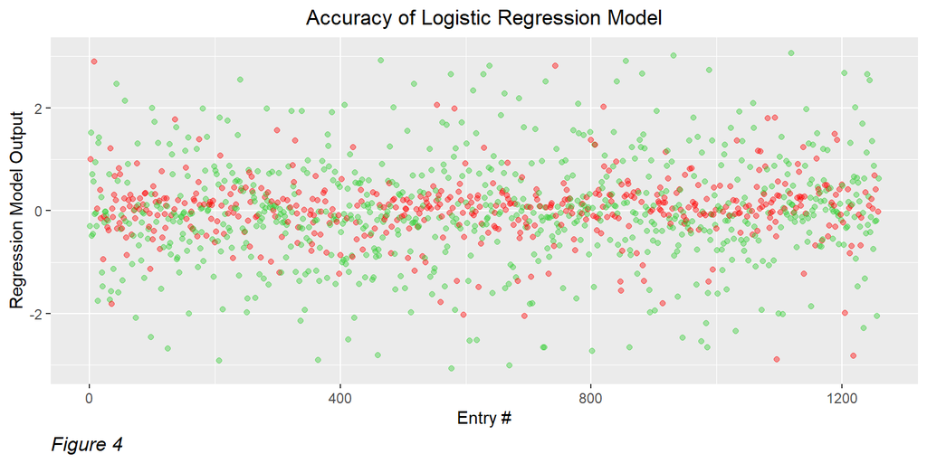

### **Conclusion**

If you have read everything up to this point, the conclusion will be of no surprise. For matches played at the World Cup, Euros, and Copa America since 1993, there is no statistically significant correlation between our three rest/freshness variables (rest days, sub usage, and extra time) and match outcomes. These findings were seen in both our individual analyses of each variable and the collective logistic regression analysis.